# Indiana Heat Map in R

Nathan Byers

January 5, 2016

This is a demonstration of how to make a heat map of Indiana. I’ll use the `choroplethr` package, along with some other packages that will make things easier:

```r
library(readxl)
library(dplyr)
library(choroplethr)
library(choroplethrMaps)
library(ggplot2)
```

I’m going to start with data at the zip code level and then scale it up to county and larger regions. Here I grab data about Indiana zip codes and counties from [www.stats.indiana.edu](http://www.stats.indiana.edu/):

```r
tmp = tempfile()
download.file(url = "http://www.stats.indiana.edu/maptools/county_zips.xls",
              destfile = tmp)
countyZIP <- read_excel(tmp, sheet = 2, skip = 1)
names(countyZIP) <- c("FIPS", "county", "zip", "percent_zip_in_county")

# filter out a row of NAs at the end and drop the last column
countyZIP <- filter(countyZIP, !is.na(county))
countyZIP <- countyZIP[, -5]

# change class to data.frame
countyZIP <- as.data.frame(countyZIP)

# take a look see
head(countyZIP)
```

```
## Source: local data frame [6 x 4]
##
##    FIPS county   zip percent_zip_in_county
##   (chr)  (chr) (chr)                 (dbl)
## 1   001  Adams 46711             99.999994
## 2   001  Adams 46714              4.910616
## 3   001  Adams 46733             98.199316
## 4   001  Adams 46740             97.094041
## 5   001  Adams 46772             99.999990
## 6   001  Adams 46773              3.629616
```

The `countyZIP` data frame has a record for every zip-county combination. If a zip code straddles two counties, then it will show up twice with the percentage of area in each county recorded in the `percent_zip_in_county` column. For simplicity I will assign one zip code to one county, based on the highest percent of zip code area.

```r
countyZIP <- group_by(countyZIP, zip)
countyZIP <- filter(countyZIP, percent_zip_in_county == max(percent_zip_in_county))
```

Now I’ll grab some income data from the IRS so I have something to plot.

```r
# this takes a while to read...
income <- read.csv("https://www.irs.gov/pub/irs-soi/13zpallagi.csv")
income <- filter(income, agi_stub == 1)
income <- select(income, zipcode, N1)
```

The `income` data frame now has the total number of tax returns that were below $25,000 for each zip code in 2013. I’ll merge this data with the `countyZIP` data frame.

```r
income$zipcode <- as.character(income$zipcode)
countyZIP <- left_join(countyZIP, income, by = c("zip" = "zipcode"))
```

Now I can plot low income data in Indiana. First I’ll plot by county. (If you would like to plot zip code areas, check out [this vignette](https://rpubs.com/arilamstein/zip-vignette-1) for the `choroplethrZip` package). To do this I need to summarize the data at the county level.

```r
county <- group_by(countyZIP, county)
county <- summarize(county, value = sum(N1, na.rm = TRUE))
```

Now I’ll plot a heat map of the low income data by county, using the `choroplethr` package.

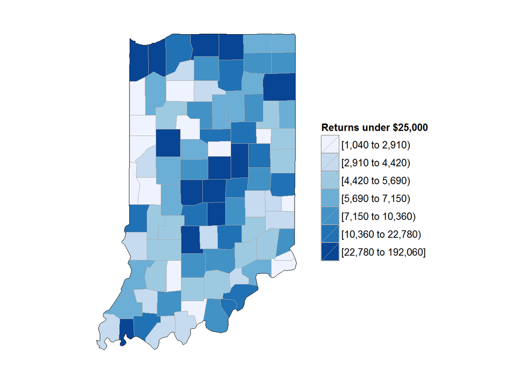

```r
county$county <- tolower(county$county)
data(county.regions)
county.regions <- filter(county.regions, state.name == "indiana")
county <- left_join(county, county.regions, by = c("county" = "county.name"))
county_map <- county_choropleth(county, legend = "Returns under $25,000",
                                state_zoom = "indiana")
county_map
```

The `choroplethr` map uses `ggplot2`, so we can customize this map just like any other `ggplot2` graph.

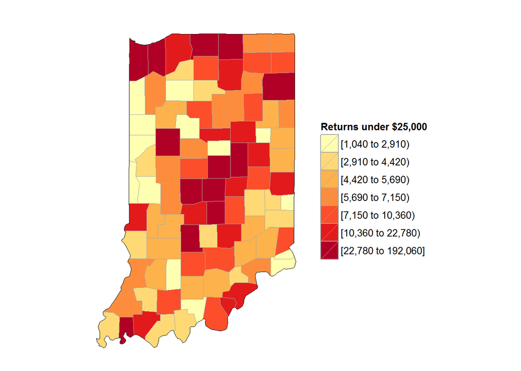

```r
county_map + scale_fill_brewer(name = "Returns under $25,000", palette = "YlOrRd")
```

But let’s say I want to make a county map with the data summarized into larger regions. For this data, it would make sense to use the [Indiana Economic Growth Regions](http://www.in.gov/dwd/2653.htm). Amazingly, I can’t find a text table that has this information, so [I made one myself](https://gist.github.com/NateByers/7553659b57a31ef82fea).

```r
growth_regions <- read.csv("https://gist.githubusercontent.com/NateByers/7553659b57a31ef82fea/raw/264c5776dde091f1d24b8710f8e983a4d717f024/economic_growth_regions", stringsAsFactors = FALSE)
```

Now I summarize the data by region and plot it.

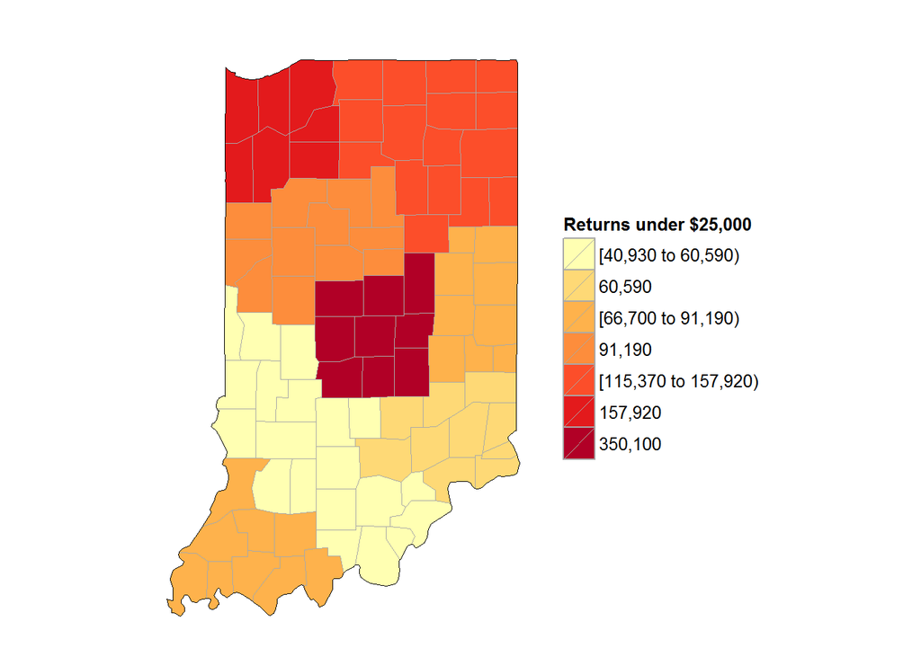

```r
regions <- left_join(county, growth_regions, by = "county")
regions <- rename(regions, county_value = value)
regions <- group_by(regions, growth_region)
regions <- mutate(regions, value = sum(county_value))
region_map <- county_choropleth(regions, state_zoom = "indiana") +
  scale_fill_brewer(name = "Returns under $25,000", palette = "YlOrRd")
region_map
```